# Лекция 1. Введение и простые решения

версия 0.5 от 15.09.2025

Хабибуллин Ринат

**Показать код**

```python
print('hello')
```

```
hello
```

# 1 Введение в дисциплину. Моделирование при исследовании скважин и пластов

## 1.1 Картинки и код для проверки

Часто для анализа уравнений неустановившейся фильтрации используются безразмерные переменные. Мы будем использовать переменные в виде:

$$r_D = \frac{r}{r_w}$$

$$t_D = \frac{kt}{\varphi \mu c_t r_w^2}$$

$$p_D = \frac{2 \pi kh}{q_s B \mu} \left( p_i - p_{wf} \right)$$

$$q_D = \frac{q}{q_{ref}}$$

Здесь использованы единицы измерения СИ.

- $q_s$ - дебит скважины на поверхности, приведенный к нормальным условиям м3/с
- $\varphi$ - пористость, доли единиц
- $\mu$ - вязкость нефти в пласте, Па с
- $B$ - объемный коэффициент нефти, м3/м3
- $p_i$ - начальное давление в пласте, Па
- $p_{wf}$ - давление забойное, Па
- $c_t$ - общая сжимаемость системы в пласте, 1/Па

Использование безразмерных переменных позволяет упростить уравнение фильтрации, которое примет вид

$$\frac{\partial p_D}{ \partial t_D} = \frac{1}{r_D} \frac{ \partial{ \left( r_D \dfrac{\partial p_D}{ \partial r_D} \right) } }{ \partial{r_D} }$$

$$\frac{\partial p_D}{ \partial t_D} = \dfrac{1}{r_D} \left[ \dfrac{\partial}{\partial r_D} \left( r_D \dfrac{ \partial p_D} {\partial r_D} \right) \right]$$

Решение этого уравнения - функция безразмерного давления от безразмерных времени и расстояния $p_D(r_D, t_D)$

Для практических расчетов удобнее бывает использовать безразмерные переменные полученные для практических метрических единиц измерения.

**Определение безразмерных переменных в практических метрических единицах**

$$r_D = \frac{r}{r_w}$$

$$t_D = \frac{0.00036 kt}{\varphi \mu c_t r_w^2}$$

$$p_D = \frac{kh}{ 18.4 q_s B \mu} \left( p_i - p_{wf} \right)$$

$$q_D = \frac{q}{q_{ref}}$$

Здесь использованы практические метрические единицы измерения.

- $q_s$ - дебит скважины на поверхности, приведенный к нормальным условиям м3/сут
- $\varphi$ - пористость, доли единиц
- $\mu$ - вязкость нефти в пласте, сП
- $B$ - объемный коэффициент нефти, м3/м3
- $p_i$ - начальное давление в пласте, атм
- $p_{wf}$ - давление забойное, атм
- $c_t$ - общая сжимаемость системы в пласте, 1/атм

## 1.2 Расчет решения с использованием python

Для работы с решениями уравнения фильтрации удобно использовать язык программирования python. Расчет на python может быть реализован на основе библиотек numpy scipy.

```python
"""
Импортируем библиотеки для расчетов.
numpy - для работы с массивами и подготовки данных
matplotlib - для построения графиков
scipy - для решения линейных уравнений
"""
import numpy as np
import matplotlib.pyplot as plt
import scipy
```

Для удобства дальнейшего изложения и использования расчетных функций при создании функций и переменных на языке python названия формируются по следующим принципам:

- сначала указывается, что расчитывается в функции, в данном случае - давление `p` или `dp`
- потом указываются пояснения - в данном случае `dp_ss` - steady state pressure
- в конце указывается размерность в которой ожидается получаение ответа - в данном случае `atma` - абсолютные атмосферы.

```python
"""
Определим функции для расчета стационарного решения
"""
def dp_ss_atm(q_liq_sm3day = 50,
               mu_cP = 1,
               b_m3m3 = 1.2,
               kh_mDm = 40,
               r_e_m = 240,
               r_m = 0.1):
  """
  функция расчета перепада давления в произвольной точке пласта
  на расстоянии r_m от центра скважины для стационарного решения
  - q_liq_sm3day - дебит жидкости на поверхности в стандартных условиях
  - mu_cP - вязкость нефти (в пластовых условиях)
  - B_m3m3 - объемный коэффициент нефти
  - kh_mDm - kh пласта
  - r_e_m - радиус контрура питания, м
  - r_m - расстояние на котором проводится расчет, м
  """
  return 18.42 * q_liq_sm3day * mu_cP * b_m3m3/ kh_mDm * np.log(r_e_m/r_m)

def p_ss_atma(p_res_atma = 250,
              q_liq_sm3day = 50,
              mu_cP = 1,
              b_m3m3 = 1.2,
              k_mD = 40,
              h_m = 10,
              r_e_m = 240,
              r_m = 0.1):
  """
  функция расчета давления в произвольной точке пласта
  на расстоянии r_m от центра скважины для стационарного решения
  - p_res_atma - пластовое давление, давление на контуре питания
  - q_liq_sm3day - дебит жидкости на поверхности в стандартных условиях
  - mu_cP - вязкость нефти (в пластовых условиях)
  - B_m3m3 - объемный коэффициент нефти
  - k_mD - проницаемость пласта
  - h_m - мощность пласта, м
  - r_e_m - радиус контрура питания, м
  - r_m - расстояние на котором проводится расчет, м
  """
  return p_res_atma - dp_ss_atm(q_liq_sm3day = q_liq_sm3day,
                                mu_cP = mu_cP,
                                b_m3m3 = b_m3m3,
                                kh_mDm = k_mD * h_m,
                                r_e_m = r_e_m,
                                r_m = r_m)
```

Функции расчетов могут быть использованы для построения графиков, например с использованием matplotlib

**Показать код**

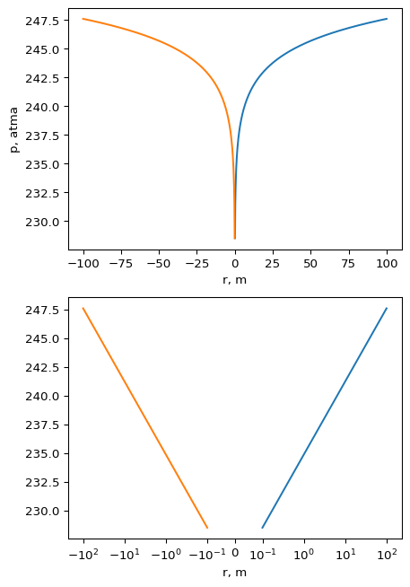

Рисунок 1.1: Распределение давления в круговом пласте

```python
"""
Построим график распределения давления в пласте
"""
# формируем массив расстояний для которых будем проводить расчет
r_arr = np.linspace(0.1, 100, 500)

# рассчитываем массив давлений на соответствующих расстояниях
# для расчета используется векторный расчет numpy - нет необходимости делать цикл в явном виде
# для примера показана передача всех аргументов созданной функции
p_arr = p_ss_atma(p_res_atma = 250,
                  q_liq_sm3day = 50,
                  mu_cP = 1,
                  b_m3m3 = 1.2,
                  k_mD = 40,
                  h_m = 10,
                  r_e_m = 240,
                  r_m = r_arr)

fig, (ax1, ax2) = plt.subplots(2, 1, figsize=(5,8))

# рисуем график в обычных координатах
ax1.plot(r_arr, p_arr)   # команда отрисовки графика по заданным массивам
ax1.plot(-r_arr, p_arr)   # отрицательная ветка
# настраиваем график

ax1.set_xlabel('r, m')
ax1.set_ylabel('p, atma')

# рисуем график в логарифмических координатах
ax2.plot(r_arr, p_arr)   # команда отрисовки графика по заданным массивам
ax2.plot(-r_arr, p_arr)   # отрицательная ветка
# настраиваем график
ax2.set_xlabel('r, m')
ax2.set_xscale('symlog', linthresh=0.1, linscale=0.6)
plt.show()
```

Для таблично заданных дебитов и времен можно оценить

$$dQ_{D(i)} = \dfrac{Q_{D(i)}-Q_{D(i-1)}}{t_{D(i)} - t_{D(i-1)} }$$

Тогда, используя принцип суперпозиции, можем выписать выражение для изменения давления на скважине и вокруг нее для произвольного момента времени

$$P_{mr.D}(t_D, r_D) = \sum_i p_D\left(t_D-t_{D(i)}, r_D, dQ_{D(i+1)} - dQ_{D(i)}\right)\cdot \mathcal{H}(t_D-t_{D(i)})
\tag{1.2}$$

## использованная литература

Щелкачев, В. Н. 1995. *Основы и приложения теории неустановившейся фильтрации. Часть 1*. Москва: Нефть и газ.